# Multivariate Regression

Mohammed alJaser

December 11, 2019

# Data Understanding

Wine variants of Portuguese “Vinho Verde” are analysed with regards to their chemical properties. Finally, we are interested how these chemical properties influence wine quality.

These are our independent variables:

1 - fixed acidity 2 - volatile acidity 3 - citric acid 4 - residual sugar 5 - chlorides 6 - free sulfur dioxide 7 - total sulfur dioxide 8 - density 9 - pH 10 - sulphates 11 - alcohol

This is our dependent variable:

12 - quality (score between 0 and 10)

## Packages

We load required packages.

```r
library(dplyr)
```

```r
library(tibble)
library(tidyr)
library(ggplot2)
library(corrplot)
library(car)
library(caret)
```

## Data Import

```r
# if file does not exist, download it first
file_path <- "./data/winequality-red.csv"
if (!file.exists(file_path)) {
  dir.create("./data")
  url <- "https://archive.ics.uci.edu/ml/machine-learning-databases/wine-quality/winequality-red.csv"
  download.file(url = url,
                destfile = file_path)
}

df <- read.csv(file_path, sep = ";")
```

## Data Summary

```r
summary(df)
```

```
##  fixed.acidity   volatile.acidity  citric.acid    residual.sugar
##  Min.   : 4.60   Min.   :0.1200   Min.   :0.000   Min.   : 0.900
##  1st Qu.: 7.10   1st Qu.:0.3900   1st Qu.:0.090   1st Qu.: 1.900
##  Median : 7.90   Median :0.5200   Median :0.260   Median : 2.200
##  Mean   : 8.32   Mean   :0.5278   Mean   :0.271   Mean   : 2.539
##  3rd Qu.: 9.20   3rd Qu.:0.6400   3rd Qu.:0.420   3rd Qu.: 2.600
##  Max.   :15.90   Max.   :1.5800   Max.   :1.000   Max.   :15.500
##    chlorides       free.sulfur.dioxide total.sulfur.dioxide    density
##  Min.   :0.01200   Min.   : 1.00       Min.   :  6.00       Min.   :0.9901
##  1st Qu.:0.07000   1st Qu.: 7.00       1st Qu.: 22.00       1st Qu.:0.9956
##  Median :0.07900   Median :14.00       Median : 38.00       Median :0.9968
##  Mean   :0.08747   Mean   :15.87       Mean   : 46.47       Mean   :0.9967
##  3rd Qu.:0.09000   3rd Qu.:21.00       3rd Qu.: 62.00       3rd Qu.:0.9978
##  Max.   :0.61100   Max.   :72.00       Max.   :289.00       Max.   :1.0037
##        pH          sulphates         alcohol         quality
##  Min.   :2.740   Min.   :0.3300   Min.   : 8.40   Min.   :3.000
##  1st Qu.:3.210   1st Qu.:0.5500   1st Qu.: 9.50   1st Qu.:5.000
##  Median :3.310   Median :0.6200   Median :10.20   Median :6.000
##  Mean   :3.311   Mean   :0.6581   Mean   :10.42   Mean   :5.636
##  3rd Qu.:3.400   3rd Qu.:0.7300   3rd Qu.:11.10   3rd Qu.:6.000
##  Max.   :4.010   Max.   :2.0000   Max.   :14.90   Max.   :8.000
```

## Visualising Correlations

There is a way to plot all multivariate correlations (although visually not so appealing). It also does not work, if there are many dimensions. You need to subset the results.

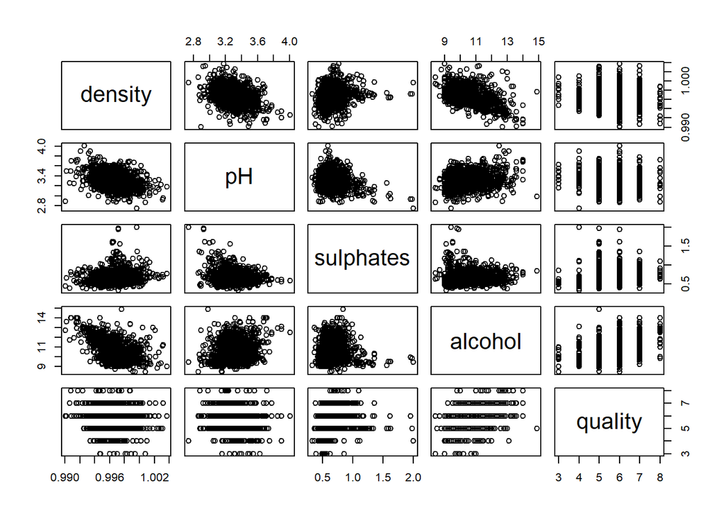

```r
pairs(df[, 8:12])
```

We create our own visualisation, that is much better to read.

```r
df_scaled <- df %>%
  scale() %>%
  as.tibble()
```

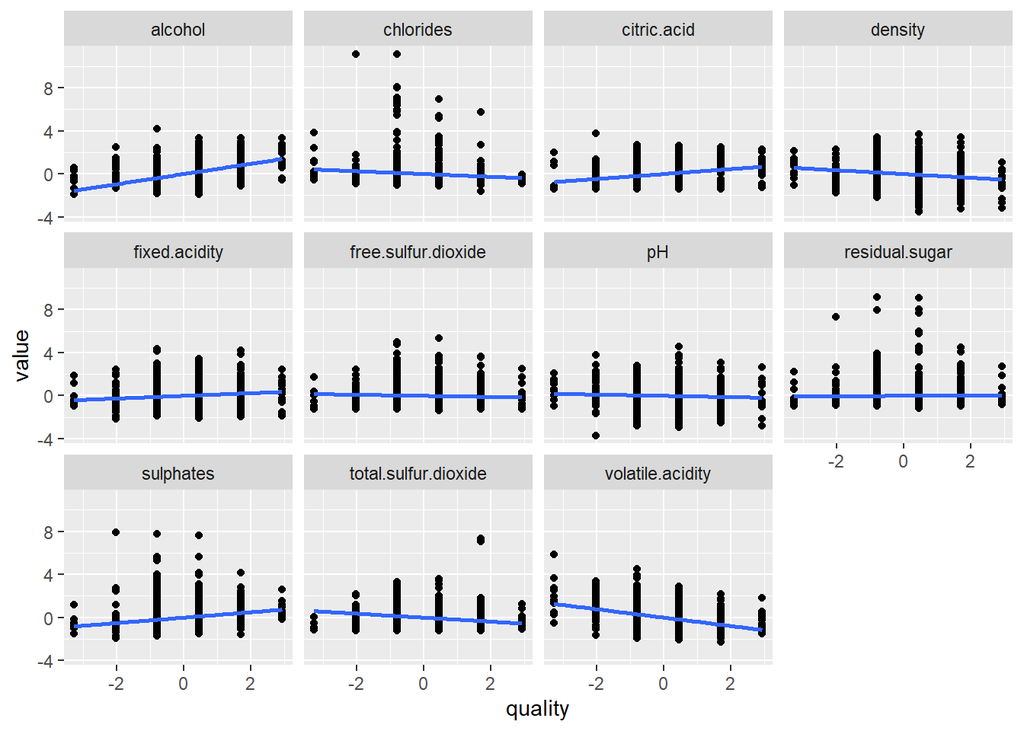

```r
df_gather <- df_scaled %>%
  gather(key = "variable", value = "value", 1:11) %>%
  mutate(variable = as.factor(variable))

g <-ggplot(df_gather, aes(x = quality, y = value))
g <- g + facet_wrap( ~ variable)
g <- g + geom_point()
g <- g + geom_smooth(se = F, method = "lm")
g
```

## Correlation Matrix

Assuming there is a linear relationship between variables, a correlation matrix is calculated.

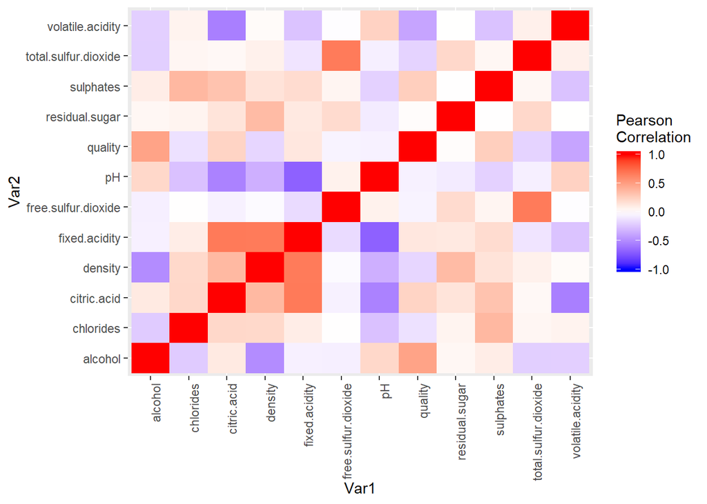

```r
cor_vals <- cor(df) %>%
  as.data.frame() %>%
  dplyr::mutate(Var1 = rownames(.)) %>%
  gather(key = "Var2", value = "Corr", 1:12)
g <- ggplot(cor_vals, aes(x = Var1, y = Var2, fill = Corr))
g <- g + geom_tile()
g <- g + scale_fill_gradient2(low = "blue", high = "red", mid = "white",
   midpoint = 0, limit = c(-1,1), space = "Lab",
   name="Pearson\nCorrelation")
g <- g + theme(axis.text.x = element_text(angle = 90, hjust = 1))
g
```

Also here we can make use of a simpler alternative: **corrplot()**.

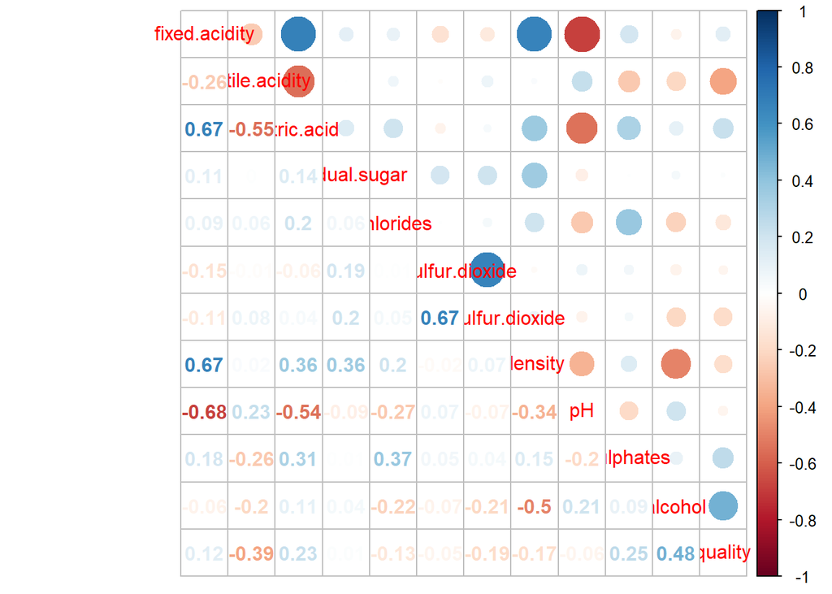

```r
cor_df <- cor(df)
corrplot.mixed(cor_df)
```

This shows in the upper right triangle correlations as circles. Size corresponds to absolute value of correlation. We are looking for large circles, because they indicate high absolute correlations. The colors correspond to positive or negative correlations. Positive correlation between X and Y means, that an increase of X leads to an increase in Y. A negative correlation between X and Y means, that an increase of X leads to a decrese in Y.

# Modeling

## Model Setup

We create a model with **lm()**.

```r
model <- lm(formula = "quality ~ .", data = df)
```

```r
summary(model)
```

```
##
## Call:
## lm(formula = "quality ~ .", data = df)
##
## Residuals:
##      Min       1Q   Median       3Q      Max
## -2.68911 -0.36652 -0.04699  0.45202  2.02498
##
## Coefficients:
##                        Estimate Std. Error t value Pr(>|t|)
## (Intercept)           2.197e+01  2.119e+01   1.036   0.3002
## fixed.acidity         2.499e-02  2.595e-02   0.963   0.3357
## volatile.acidity     -1.084e+00  1.211e-01  -8.948  < 2e-16 ***
## citric.acid          -1.826e-01  1.472e-01  -1.240   0.2150
## residual.sugar        1.633e-02  1.500e-02   1.089   0.2765
## chlorides            -1.874e+00  4.193e-01  -4.470 8.37e-06 ***
## free.sulfur.dioxide   4.361e-03  2.171e-03   2.009   0.0447 *
## total.sulfur.dioxide -3.265e-03  7.287e-04  -4.480 8.00e-06 ***
## density              -1.788e+01  2.163e+01  -0.827   0.4086
## pH                   -4.137e-01  1.916e-01  -2.159   0.0310 *
## sulphates             9.163e-01  1.143e-01   8.014 2.13e-15 ***
## alcohol               2.762e-01  2.648e-02  10.429  < 2e-16 ***
## ---
## Signif. codes:  0 '***' 0.001 '**' 0.01 '*' 0.05 '.' 0.1 ' ' 1
##
## Residual standard error: 0.648 on 1587 degrees of freedom
## Multiple R-squared:  0.3606, Adjusted R-squared:  0.3561
## F-statistic: 81.35 on 11 and 1587 DF,  p-value: < 2.2e-16
```

We see which parameters are statistically relevant, and what the parameter values are.

## Predictions

Now, we can create predictions.

```r
df$quality_pred <- predict(object = model,
                              newdata = df)
```

Predicted values and true values are visualised as correlation plot. A linear regression line is drawed for reference. Also a black line is drawed as reference for a perfect regression, in which predicted values and actual values are identical.

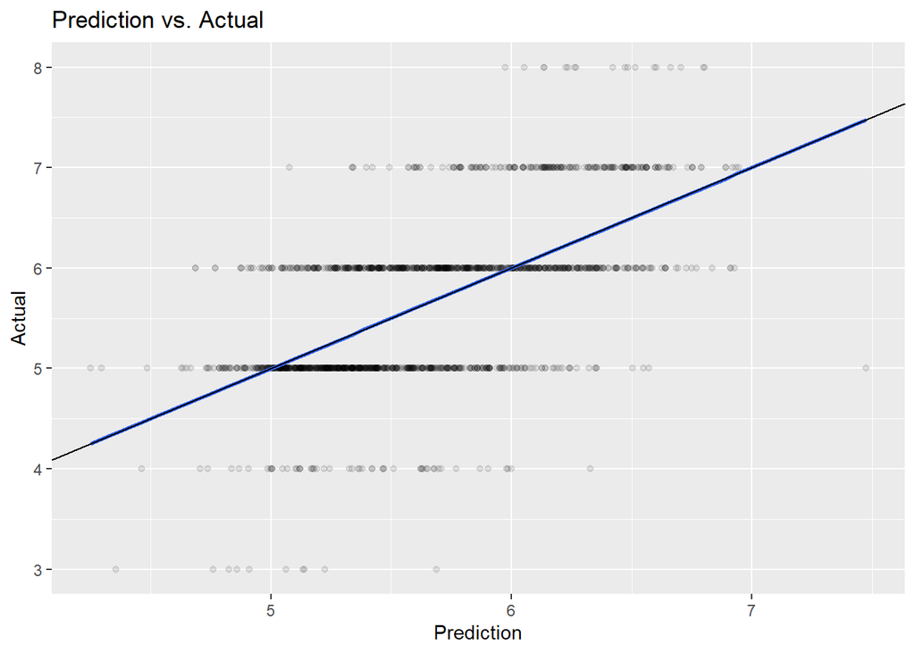

```r
g <- ggplot(df, aes(y = quality, x = quality_pred))
g <- g + geom_point(alpha = .1)
g <- g + geom_smooth(method = "lm", se = F)
g <- g + geom_abline(slope = 1, intercept = 0)
g <- g + ylab ("Actual")
g <- g + xlab ("Prediction")
g <- g + ggtitle ("Prediction vs. Actual")
g
```

## Model Performance

We calculate adjusted R-squared to analyse model performance. R-squared is a measure that indicates how much of variability in data is explained by the model.

```r
model_summary <- summary(model)
model_summary$adj.r.squared
```

```
## [1] 0.3561195
```

You should use adjusted R-squared, because R-squared always increases when more explanatory variables are added to a model. Its value will always be less or equal to R-squared.

Model quality is far from perfect, but reasonably good.

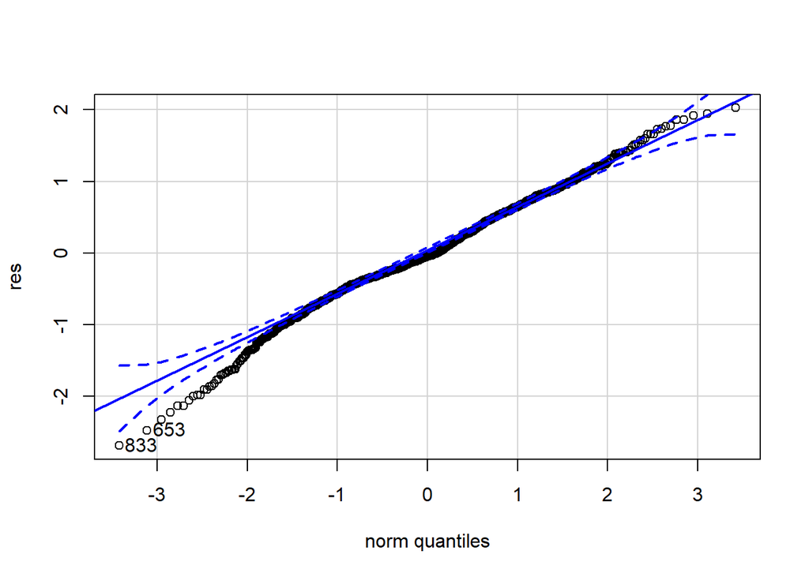

```
## [1] 833 653
```

```r
res <- residuals(object = model)
qqPlot(res)
```

# Acknowledgement

This dataset was provided by:

P. Cortez, A. Cerdeira, F. Almeida, T. Matos and J. Reis. Modeling wine preferences by data mining from physicochemical properties. In Decision Support Systems, Elsevier, 47(4):547-553, 2009.